# DS2 Lab2 - Classification, Stacking

Data Science 2: Machine Learning Tools - CEU 2021

Janos K. Divenyi, Jeno Pal

2021-03-11

```r
library(tidyverse)
theme_set(theme_minimal())

library(h2o)
h2o.init()
```

```
##  Connection successful!
##
## R is connected to the H2O cluster:
##     H2O cluster uptime:         9 hours 26 minutes
##     H2O cluster timezone:       Europe/Budapest
##     H2O data parsing timezone:  UTC
##     H2O cluster version:        3.32.0.4
##     H2O cluster version age:    1 month and 4 days
##     H2O cluster name:           H2O_started_from_R_jdivenyi_xnf363
##     H2O cluster total nodes:    1
##     H2O cluster total memory:   7.47 GB
##     H2O cluster total cores:    8
##     H2O cluster allowed cores:  8
##     H2O cluster healthy:        TRUE
##     H2O Connection ip:          localhost
##     H2O Connection port:        54321
##     H2O Connection proxy:       NA
##     H2O Internal Security:      FALSE
##     H2O API Extensions:         Amazon S3, XGBoost, Algos, AutoML, Core V3, TargetEncoder, Core V4
##     R Version:                  R version 4.0.3 (2020-10-10)
```

```r
h2o.no_progress()

my_seed <- 20210311
```

## Basic classification with simple models on h2o

```r
data <- read_csv("https://raw.githubusercontent.com/pappzoltan/machine-learning-course/master/data/airlines/airline100K.csv")
skimr::skim(data)
```

Data summary

| Name | data |
| --- | --- |
| Number of rows | 100000 |
| Number of columns | 9 |
| _______________________ |  |
| Column type frequency: |  |
| character | 7 |
| numeric | 2 |
| ________________________ |  |
| Group variables | None |

**Variable type: character**

| skim_variable | n_missing | complete_rate | min | max | empty | n_unique | whitespace |
| --- | --- | --- | --- | --- | --- | --- | --- |
| Month | 0 | 1 | 3 | 4 | 0 | 12 | 0 |
| DayofMonth | 0 | 1 | 3 | 4 | 0 | 31 | 0 |
| DayOfWeek | 0 | 1 | 3 | 3 | 0 | 7 | 0 |
| UniqueCarrier | 0 | 1 | 2 | 2 | 0 | 22 | 0 |
| Origin | 0 | 1 | 3 | 3 | 0 | 289 | 0 |
| Dest | 0 | 1 | 3 | 3 | 0 | 289 | 0 |
| dep_delayed_15min | 0 | 1 | 1 | 1 | 0 | 2 | 0 |

**Variable type: numeric**

| skim_variable | n_missing | complete_rate | mean | sd | p0 | p25 | p50 | p75 | p100 | hist |
| --- | --- | --- | --- | --- | --- | --- | --- | --- | --- | --- |
| DepTime | 0 | 1 | 1341.52 | 476.38 | 1 | 931 | 1330 | 1733 | 2534 | ▁▇▇▇▂ |
| Distance | 0 | 1 | 729.40 | 574.62 | 30 | 317 | 575 | 957 | 4962 | ▇▂▁▁▁ |

```r
data <- mutate(data,
  across(where(is.character), as.factor),
  DepHour = factor(floor(DepTime / 100)),
  DepTime = NULL
)
skimr::skim(data)
```

Data summary

| Name | data |
| --- | --- |
| Number of rows | 100000 |
| Number of columns | 9 |
| _______________________ |  |
| Column type frequency: |  |
| factor | 8 |
| numeric | 1 |
| ________________________ |  |
| Group variables | None |

**Variable type: factor**

| skim_variable | n_missing | complete_rate | ordered | n_unique | top_counts |
| --- | --- | --- | --- | --- | --- |
| Month | 0 | 1 | FALSE | 12 | c-8: 8830, c-7: 8706, c-3: 8595, c-5: 8543 |
| DayofMonth | 0 | 1 | FALSE | 31 | c-1: 3399, c-2: 3380, c-6: 3377, c-2: 3374 |
| DayOfWeek | 0 | 1 | FALSE | 7 | c-4: 14736, c-5: 14657, c-2: 14604, c-1: 14569 |
| UniqueCarrier | 0 | 1 | FALSE | 22 | WN: 15082, AA: 9418, DL: 8128, MQ: 7443 |
| Origin | 0 | 1 | FALSE | 289 | ATL: 5834, ORD: 4870, DFW: 4270, LAX: 3259 |
| Dest | 0 | 1 | FALSE | 289 | ATL: 5795, ORD: 4933, DFW: 4337, LAX: 3205 |
| dep_delayed_15min | 0 | 1 | FALSE | 2 | N: 80956, Y: 19044 |
| DepHour | 0 | 1 | FALSE | 26 | 8: 6620, 17: 6562, 9: 6409, 10: 6363 |

**Variable type: numeric**

| skim_variable | n_missing | complete_rate | mean | sd | p0 | p25 | p50 | p75 | p100 | hist |
| --- | --- | --- | --- | --- | --- | --- | --- | --- | --- | --- |
| Distance | 0 | 1 | 729.4 | 574.62 | 30 | 317 | 575 | 957 | 4962 | ▇▂▁▁▁ |

```r
data_split <- h2o.splitFrame(as.h2o(data), ratios = 0.6, seed = my_seed)
data_train <- data_split[[1]]
data_test <- data_split[[2]]

y <- "dep_delayed_15min"
X <- setdiff(names(data_train), c(y, "Dest", "Origin"))
```

```r
simple_lm <- h2o.glm(
  X, y,
  training_frame = data_train,
  model_id = "logit",  # h2o recognize from the factor outcome that it should estimate a logit
  lambda = 0,
  nfolds = 5,
  seed = my_seed
)
simple_lm
```

```
## Model Details:
## ==============
##
## H2OBinomialModel: glm
## Model ID:  logit
## GLM Model: summary
##     family  link regularization number_of_predictors_total
## 1 binomial logit           None                         94
##   number_of_active_predictors number_of_iterations  training_frame
## 1                          94                    6 RTMP_sid_b2dc_3
##
## Coefficients: glm coefficients
##             names coefficients standardized_coefficients
## 1       Intercept     0.239179                  0.238355
## 2 DayofMonth.c-10     0.049983                  0.049983
## 3 DayofMonth.c-11     0.078757                  0.078757
## 4 DayofMonth.c-12     0.079163                  0.079163
## 5 DayofMonth.c-13     0.062253                  0.062253
##
## ---
##            names coefficients standardized_coefficients
## 90 DayOfWeek.c-3    -0.066558                 -0.066558
## 91 DayOfWeek.c-4     0.147551                  0.147551
## 92 DayOfWeek.c-5     0.240252                  0.240252
## 93 DayOfWeek.c-6    -0.098889                 -0.098889
## 94 DayOfWeek.c-7    -0.046255                 -0.046255
## 95      Distance    -0.000001                 -0.000650
##
## H2OBinomialMetrics: glm
## ** Reported on training data. **
##
## MSE:  0.1399579
## RMSE:  0.3741094
## LogLoss:  0.4398481
## Mean Per-Class Error:  0.3499583
## AUC:  0.7125608
## AUCPR:  0.3641934
## Gini:  0.4251215
## R^2:  0.09157045
## Residual Deviance:  52767.7
```

[output cut: 88 more lines]

```
## ---
##                         mean           sd  cv_1_valid cv_2_valid  cv_3_valid
## precision         0.31134805  0.013390825  0.31892523  0.2936337    0.308569
## r2                0.08745938  0.005752005 0.092569254 0.08893569 0.078751355
## recall             0.6264833  0.036863785  0.60612786  0.6785876  0.61480236
## residual_deviance   10603.82     277.4055    10425.37   10339.22    11016.64
## rmse              0.37489986 0.0044433083  0.37378258 0.37073132  0.38159597
## specificity       0.67350745   0.03230911  0.69616425  0.6291268  0.66247684
##                   cv_4_valid cv_5_valid
## precision         0.32909572 0.30651668
## r2                0.09212385 0.08491675
## recall             0.5850746  0.6478241
## residual_deviance  10751.375  10486.495
## rmse              0.37688866  0.3715008
## specificity        0.7126272 0.66714215
```

```r
h2o.auc(simple_lm, train = TRUE, xval = TRUE)
```

```
##     train      xval
## 0.7125608 0.7086395
```

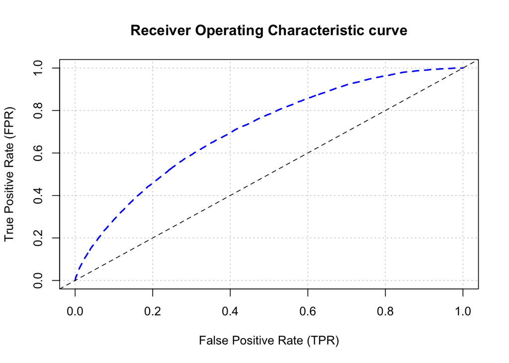

```r
plot(h2o.performance(simple_lm, xval = TRUE), type = "roc")
```

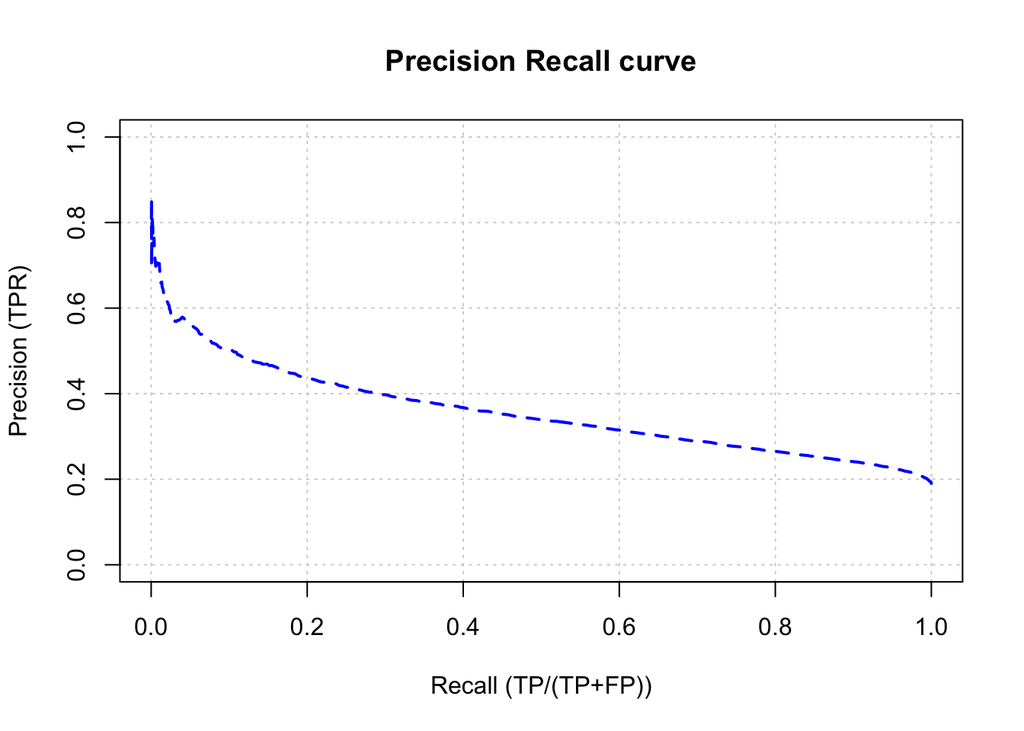

```r
plot(h2o.performance(simple_lm, xval = TRUE), type = "pr")
```

```r
simple_tree <- h2o.randomForest(
  X, y,
  training_frame = data_train,
  model_id = "simple_tree",
  ntrees = 1, mtries = length(X), sample_rate = 1,
  max_depth = 2,
  nfolds = 5,
  seed = my_seed
)
simple_tree
```

```
## Model Details:
## ==============
##
## H2OBinomialModel: drf
## Model ID:  simple_tree
## Model Summary:
##   number_of_trees number_of_internal_trees model_size_in_bytes min_depth
## 1               1                        1                 108         2
##   max_depth mean_depth min_leaves max_leaves mean_leaves
## 1         2    2.00000          4          4     4.00000
##
##
## H2OBinomialMetrics: drf
## ** Reported on training data. **
## ** Metrics reported on Out-Of-Bag training samples **
##
## MSE:  NaN
## RMSE:  NaN
## LogLoss:  NaN
## Mean Per-Class Error:  NaN
## AUC:  NaN
## AUCPR:  NaN
## Gini:  NaN
## R^2:  NaN
##
## Confusion Matrix (vertical: actual; across: predicted) for F1-optimal threshold:
##         N  Y Error    Rate
## N      NA NA    NA  =NA/NA
## Y      NA NA    NA  =NA/NA
## Totals NA NA    NA  =NA/NA
##
## Maximum Metrics: Maximum metrics at their respective thresholds
##                         metric threshold value idx
## 1                       max f1        NA    NA  -1
## 2                       max f2        NA    NA  -1
## 3                 max f0point5        NA    NA  -1
## 4                 max accuracy        NA    NA  -1
## 5                max precision        NA    NA  -1
## 6                   max recall        NA    NA  -1
## 7              max specificity        NA    NA  -1
```

[output cut: 69 more lines]

```
## ---
##                   mean           sd cv_1_valid  cv_2_valid  cv_3_valid
## pr_auc      0.30208537  0.008831842  0.3090477  0.29022232  0.29657862
## precision    0.2729961  0.007957296 0.27002874  0.26216215  0.27488396
## r2          0.06326093 0.0072301365 0.06965998 0.059362575 0.052639473
## recall       0.7117139   0.05473758 0.75133216   0.7464916  0.67241377
## rmse         0.3798376 0.0046113464  0.3784715  0.37670022  0.38696617
## specificity  0.5533138  0.050368484 0.52324367   0.5226782   0.5654234
##              cv_4_valid cv_5_valid
## pr_auc       0.31166616  0.3029121
## precision    0.27382612  0.2840795
## r2          0.069214165 0.06542845
## recall        0.7535181 0.63481385
## rmse          0.3816143 0.37543583
## specificity  0.51854515  0.6366786
```

Normally, the result of `h2o.randomForest` is a collection of trees. You can extract one of the models and look at its description. (Unfortunately, plotting is much more cumbersome.)

```r
tree_model <- h2o.getModelTree(simple_tree, 1)  # gets the first tree which is the only one now
cat(tree_model@tree_decision_path)  # for some reason, here the predicted value is for "N" (not delayed)
```

```
## If ( DepHour is in [ 10 11 12 13 4 5 6 7 8 9 ]) {
##
##  If ( DepHour is in [ 4 5 6 7 8 ]) {
##
##      Predicted value: 0.9504715
##
##  } else if ( DepHour is in [ 10 11 12 13 9 ]) {
##
##      Predicted value: 0.8480189
##
##  }
## } else if ( DepHour is in [ 0 1 14 15 16 17 18 19 2 20 21 22 23 24 25 3 ]) {
##
##  If ( DepHour is in [ 14 15 16 17 18 19 ]) {
##
##      Predicted value: 0.7533776
##
##  } else if ( DepHour is in [ 0 1 2 20 21 22 23 24 25 3 ]) {
##
##      Predicted value: 0.61281854
##
##  }
## }
```

```r
h2o.auc(simple_tree, train = TRUE, xval = TRUE)
```

```
##              train               xval
##              "NaN" "0.67708609473995"
```

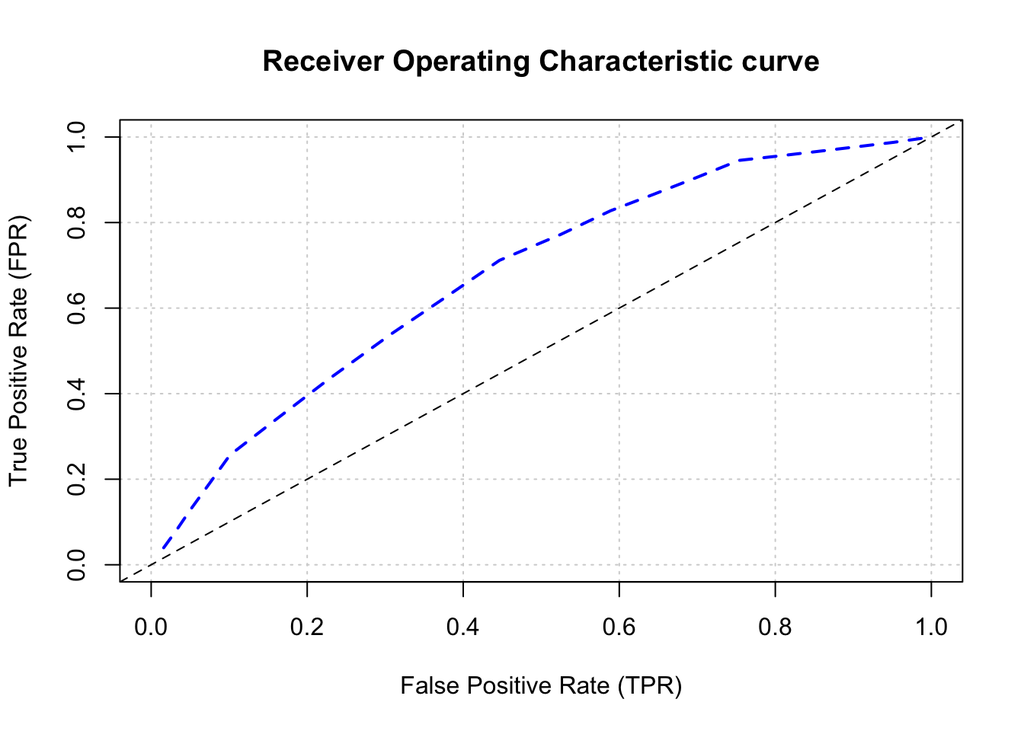

```r
plot(h2o.performance(simple_tree, xval = TRUE), type = "roc")
```

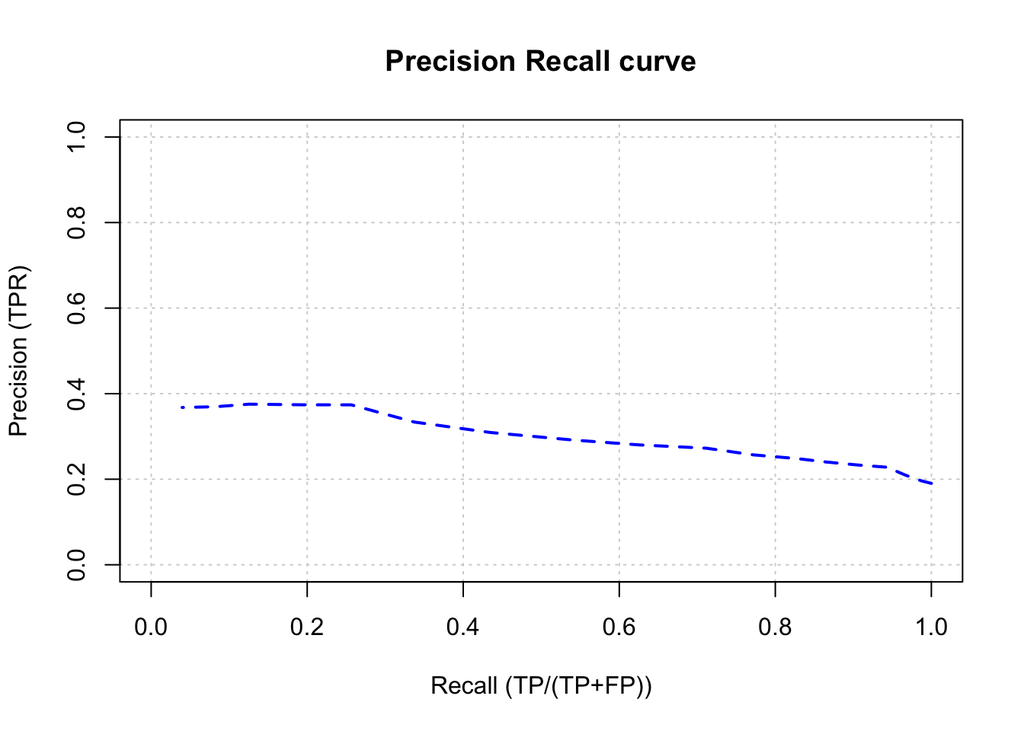

```r
plot(h2o.performance(simple_tree, xval = TRUE), type = "pr")
```

```r
# get prediction
predict(simple_lm, data_test[1:100,])
```

```
##   predict         N          Y
## 1       Y 0.6531832 0.34681679
## 2       N 0.8368203 0.16317970
## 3       N 0.8266696 0.17333043
## 4       N 0.9411370 0.05886301
## 5       N 0.8907011 0.10929887
## 6       N 0.9329090 0.06709096
##
## [100 rows x 3 columns]
```

```r
predict(simple_tree, data_test[1:100,])
```

```
##   predict         N          Y
## 1       N 0.7533776 0.24662238
## 2       N 0.7533776 0.24662238
## 3       N 0.7533776 0.24662238
## 4       N 0.9504715 0.04952848
## 5       N 0.9504715 0.04952848
## 6       N 0.9504715 0.04952848
##
## [100 rows x 3 columns]
```

### Comparison of models using ROC / PR plots

The default ROC plot is nice but is only capable of showing one model. If we want to compare multiple models on the same chart, we should calculate the metrics for varying thresholds. You might implement this using a simple loop on the predictions. Or you can just extract the calculated metrics from the `h2o.performance` object.

```r
getPerformanceMetrics <- function(model, newdata = NULL, xval = FALSE) {
  h2o.performance(model, newdata = newdata, xval = xval)@metrics$thresholds_and_metric_scores %>%
    as_tibble() %>%
    mutate(model = model@model_id)
}
tree_performance <- getPerformanceMetrics(simple_tree, xval = TRUE)
tree_performance
```

| threshold | f1 | f2 | f0point5 | accuracy | precision | recall | specificity | absolute_mcc | min_per_class_accuracy | mean_per_class_accuracy | tns | fns | fps | tps | tnr | fnr | fpr | tpr | idx | model |
| --- | --- | --- | --- | --- | --- | --- | --- | --- | --- | --- | --- | --- | --- | --- | --- | --- | --- | --- | --- | --- |
| 0.39176047 | 0.07164887 | 0.04831072 | 0.1386084 | 0.8042978 | 0.3676948 | 0.03969158 | 0.98396162 | 0.06545785 | 0.03969158 | 0.5118266 | 47792 | 10960 | 779 | 453 | 0.98396162 | 0.96030842 | 0.01603838 | 0.03969158 | 0 | simple_tree |
| 0.39127904 | 0.13481375 | 0.09761613 | 0.2178140 | 0.7986463 | 0.3694543 | 0.08244984 | 0.96693500 | 0.09613283 | 0.08244984 | 0.5246924 | 46965 | 10472 | 1606 | 941 | 0.96693500 | 0.91755016 | 0.03306500 | 0.08244984 | 1 | simple_tree |
| 0.38716513 | 0.18818122 | 0.14483818 | 0.2685432 | 0.7938784 | 0.3754257 | 0.12555857 | 0.95091721 | 0.12297326 | 0.12555857 | 0.5382379 | 46187 | 9980 | 2384 | 1433 | 0.95091721 | 0.87444143 | 0.04908279 | 0.12555857 | 2 | simple_tree |
| 0.35634714 | 0.25523810 | 0.21439376 | 0.3153076 | 0.7848926 | 0.3739851 | 0.19372645 | 0.92380227 | 0.15476723 | 0.19372645 | 0.5587644 | 44870 | 9202 | 3701 | 2211 | 0.92380227 | 0.80627355 | 0.07619773 | 0.19372645 | 3 | simple_tree |
| 0.35616612 | 0.30423033 | 0.27364859 | 0.3425074 | 0.7768071 | 0.3738664 | 0.25646193 | 0.89907558 | 0.18122681 | 0.25646193 | 0.5777688 | 43669 | 8486 | 4902 | 2927 | 0.89907558 | 0.74353807 | 0.10092442 | 0.25646193 | 4 | simple_tree |
| 0.25792634 | 0.33546813 | 0.33658554 | 0.3343581 | 0.7457155 | 0.3336222 | 0.33733462 | 0.84167507 | 0.17825515 | 0.33733462 | 0.5895048 | 40881 | 7563 | 7690 | 3850 | 0.84167507 | 0.66266538 | 0.15832493 | 0.33733462 | 5 | simple_tree |
| 0.24658167 | 0.36139137 | 0.40206503 | 0.3281909 | 0.7077054 | 0.3092507 | 0.43467975 | 0.77185975 | 0.18315652 | 0.43467975 | 0.6032698 | 37490 | 6452 | 11081 | 4961 | 0.77185975 | 0.56532025 | 0.22814025 | 0.43467975 | 6 | simple_tree |
| 0.23884976 | 0.37874081 | 0.46118468 | 0.3213030 | 0.6632602 | 0.2918009 | 0.53947253 | 0.69234729 | 0.19055147 | 0.53947253 | 0.6159099 | 33628 | 5256 | 14943 | 6157 | 0.69234729 | 0.46052747 | 0.30765271 | 0.53947253 | 7 | simple_tree |
| 0.22910702 | 0.38701101 | 0.50161039 | 0.3150368 | 0.6232995 | 0.2802861 | 0.62498905 | 0.62290256 | 0.19687254 | 0.62290256 | 0.6239458 | 30255 | 4280 | 18316 | 7133 | 0.62290256 | 0.37501095 | 0.37709744 | 0.62498905 | 8 | simple_tree |
| 0.22849280 | 0.39408054 | 0.53817305 | 0.3108519 | 0.5836223 | 0.2724863 | 0.71164462 | 0.55354018 | 0.20818042 | 0.55354018 | 0.6325924 | 26886 | 3291 | 21685 | 8122 | 0.55354018 | 0.28835538 | 0.44645982 | 0.71164462 | 9 | simple_tree |

[output cut: 10 more lines]

Plot ROC curve

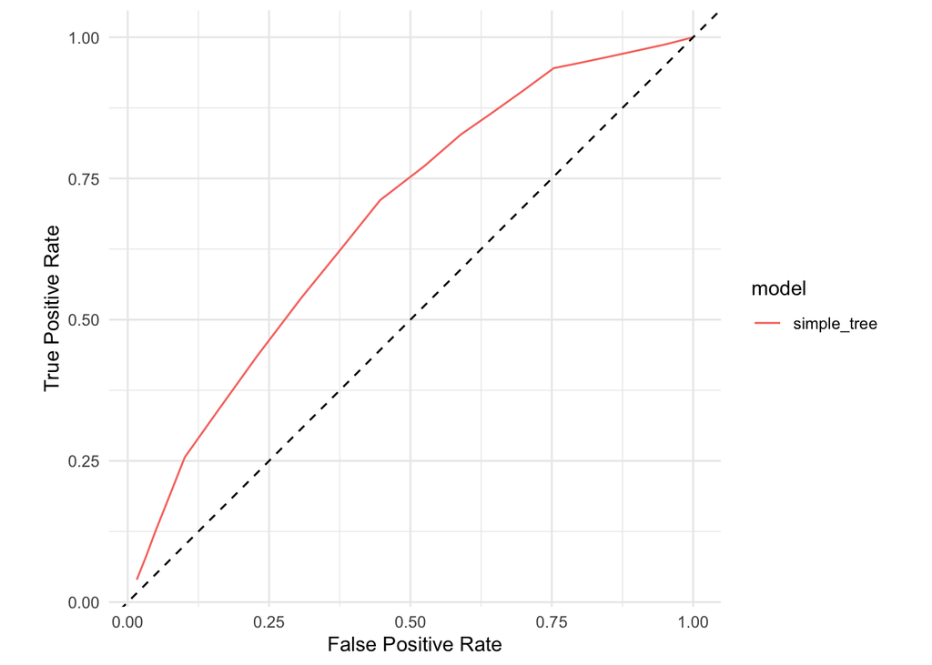

```r
plotROC <- function(performance_df) {
  ggplot(performance_df, aes(fpr, tpr, color = model)) +
    geom_path() +
    geom_abline(slope = 1, intercept = 0, linetype = "dashed") +
    coord_fixed() +
    labs(x = "False Positive Rate", y = "True Positive Rate")
}
plotROC(tree_performance)
```

Plot RP curve

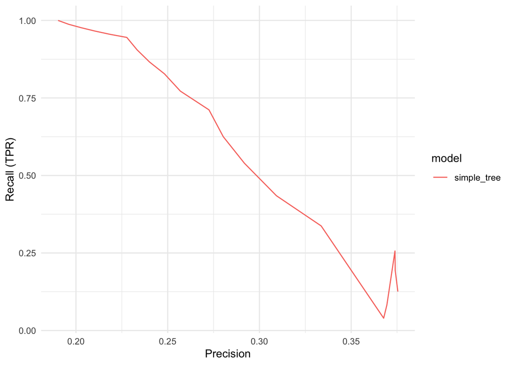

```r
plotRP <- function(performance_df) {
  ggplot(performance_df, aes(precision, tpr, color = model)) +  # tpr = recall
    geom_line() +
    labs(x = "Precision", y = "Recall (TPR)")
}
plotRP(tree_performance)
```

Compare

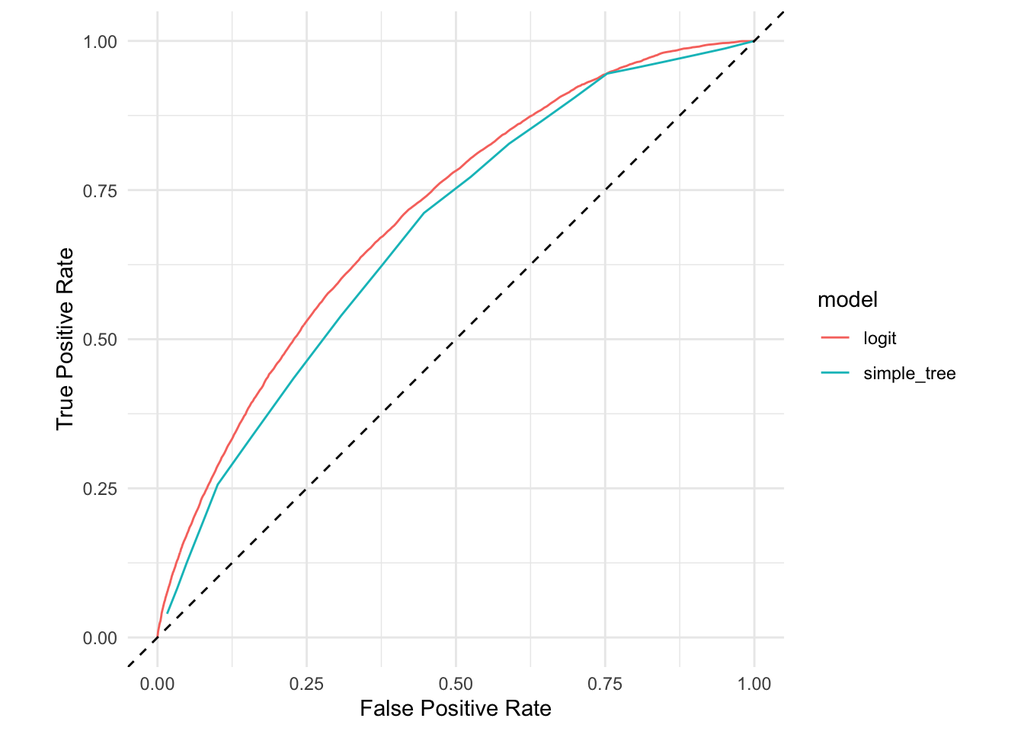

```r
simple_models <- list(simple_lm, simple_tree)
simple_models_performance <- map_df(simple_models, getPerformanceMetrics, xval = TRUE)
plotROC(simple_models_performance)
```

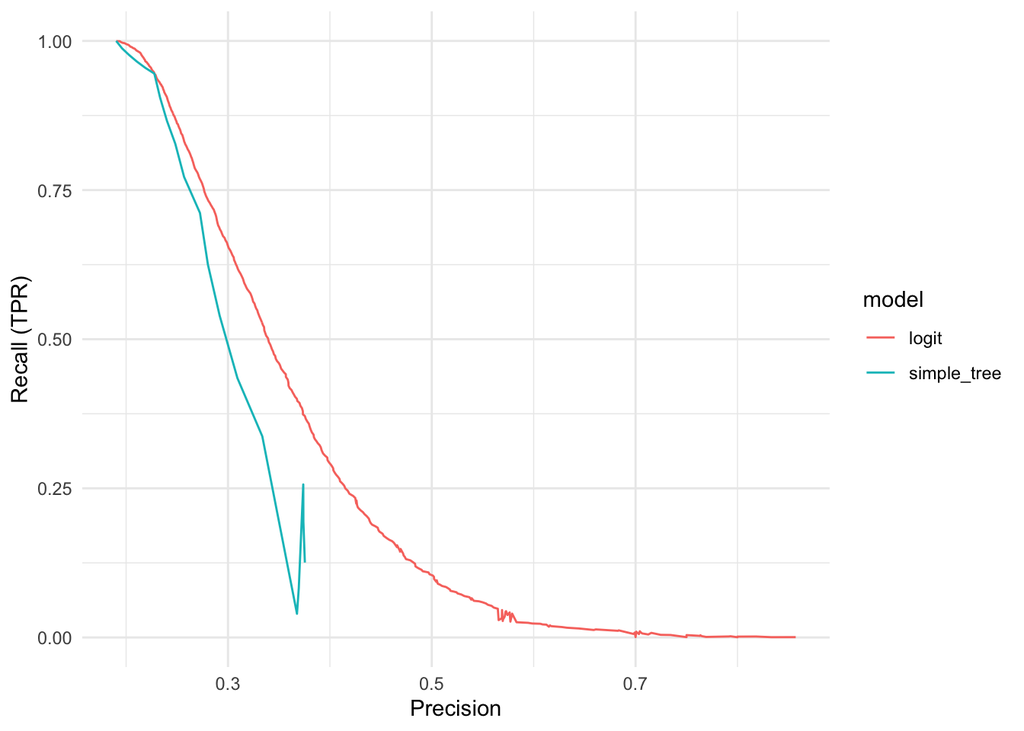

```r
plotRP(simple_models_performance)
```

## Stacking:

The idea is similar to tree-ensembles of random forests and gradient boosted trees, but here we want to aggregate strong models and instead of simply averaging the predictions of the base models, you can train a new meta-learner to find the best combination: - specify different $L$ predictive models - score training observations using out-of-fold predictions - this gives a “level-one” data: the original outcome and the scores coming from the $L$ base models - use these to estimate a second level predictive model (“meta-learner”)

When predicting new observations - the base models are estimated using all training observations, use these to get scores for the new observation - input this to the meta-learner model to get the predicted outcome

The more uncorrelated predictions are, the more room there is to improve individual models by aggregating them.

Stacked models do not always perform better than individual ones but many times they do.

It is very convenient to create stacked ensembles in h2o, we are gaining practice with this now. See more [here](http://docs.h2o.ai/h2o/latest-stable/h2o-docs/data-science/stacked-ensembles.html).

### Train some base learners

Train some base learners using cross validation.

```r
glm_model <- h2o.glm(
  X, y,
  training_frame = data_train,
  model_id = "lasso",
  family = "binomial",
  alpha = 1,
  lambda_search = TRUE,
  seed = my_seed,
  nfolds = 5,
  keep_cross_validation_predictions = TRUE  # this is necessary to perform later stacking
)
```

```r
rf_model <- h2o.randomForest(
  X, y,
  training_frame = data_train,
  model_id = "rf",
  ntrees = 200,
  max_depth = 10,
  seed = my_seed,
  nfolds = 5,
  keep_cross_validation_predictions = TRUE
)
```

```r
gbm_model <- h2o.gbm(
  X, y,
  training_frame = data_train,
  model_id = "gbm",
  ntrees = 200,
  max_depth = 5,
  learn_rate = 0.1,
  seed = my_seed,
  nfolds = 5,
  keep_cross_validation_predictions = TRUE
)
```

```r
deeplearning_model <- h2o.deeplearning(
  X, y,
  training_frame = data_train,
  model_id = "deeplearning",
  hidden = c(32, 8),
  seed = my_seed,
  nfolds = 5,
  keep_cross_validation_predictions = TRUE
)
```

### Performance comparison

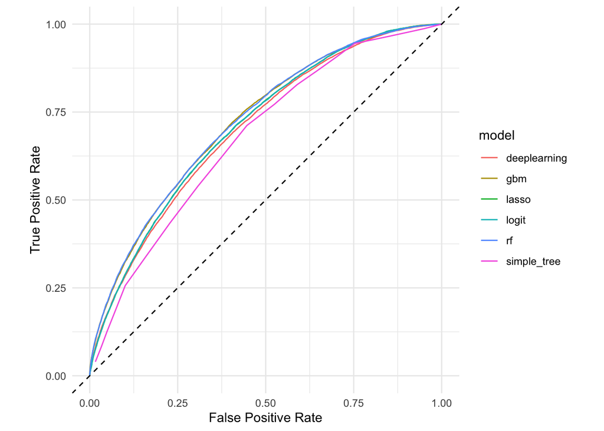

```r
my_models <- list(glm_model, rf_model, gbm_model, deeplearning_model)
all_performance <- map_df(c(simple_models, my_models), getPerformanceMetrics, xval = TRUE)
plotROC(all_performance)
```

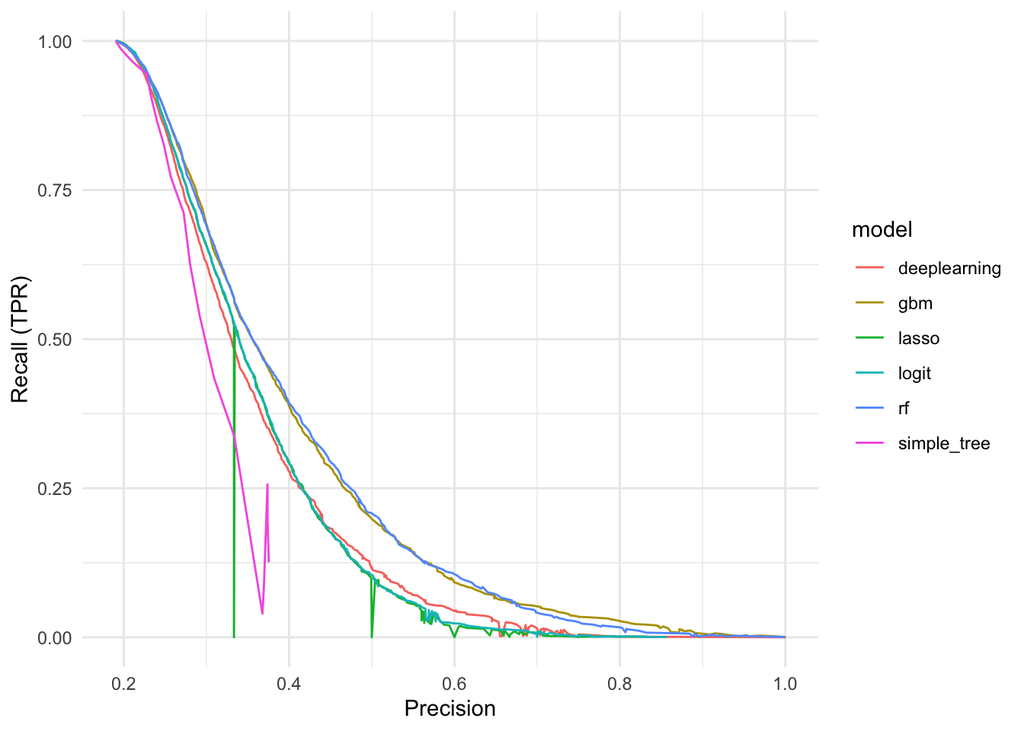

```r
plotRP(all_performance)
```

### Stacking base learners

You can combine models estimated on the same training set, using the same procedure for cross-validation (the seed should also be the same so the random folds are the same as well).

```r
ensemble_model <- h2o.stackedEnsemble(
  X, y,
  training_frame = data_train,
  base_models = my_models,
  keep_levelone_frame = TRUE
)
ensemble_model
```

```
## Model Details:
## ==============
##
## H2OBinomialModel: stackedensemble
## Model ID:  StackedEnsemble_model_R_1614936962565_7652
## Number of Base Models: 4
##
## Base Models (count by algorithm type):
##
## deeplearning          drf          gbm          glm
##            1            1            1            1
##
## Metalearner:
##
## Metalearner algorithm: glm
## Metalearner hyperparameters:
##
##
## H2OBinomialMetrics: stackedensemble
## ** Reported on training data. **
##
## MSE:  0.1175124
## RMSE:  0.3428009
## LogLoss:  0.3806091
## Mean Per-Class Error:  0.2722163
## AUC:  0.8260671
## AUCPR:  0.5658706
## Gini:  0.6521341
##
## Confusion Matrix (vertical: actual; across: predicted) for F1-optimal threshold:
##           N    Y    Error         Rate
## N      6918 1252 0.153244   =1252/8170
## Y       737 1147 0.391189    =737/1884
## Totals 7655 2399 0.197832  =1989/10054
##
## Maximum Metrics: Maximum metrics at their respective thresholds
##                         metric threshold       value idx
## 1                       max f1  0.238897    0.535606 219
## 2                       max f2  0.164658    0.650155 279
## 3                 max f0point5  0.376930    0.555749 141
## 4                 max accuracy  0.384988    0.843744 137
## 5                max precision  0.918075    1.000000   0
## 6                   max recall  0.073184    1.000000 378
## 7              max specificity  0.918075    1.000000   0
## 8             max absolute_mcc  0.241954    0.417800 217
## 9   max min_per_class_accuracy  0.189907    0.737261 256
## 10 max mean_per_class_accuracy  0.181663    0.739592 263
## 11                     max tns  0.918075 8170.000000   0
## 12                     max fns  0.918075 1883.000000   0
## 13                     max fps  0.057053 8170.000000 399
## 14                     max tps  0.073184 1884.000000 378
## 15                     max tnr  0.918075    1.000000   0
## 16                     max fnr  0.918075    0.999469   0
## 17                     max fpr  0.057053    1.000000 399
## 18                     max tpr  0.073184    1.000000 378
##
## Gains/Lift Table: Extract with `h2o.gainsLift(<model>, <data>)` or `h2o.gainsLift(<model>, valid=<T/F>, xval=<T/F>)`
```

```r
ensemble_model@model$metalearner_model@model$coefficients_table
```

| names | coefficients | standardized_coefficients |
| --- | --- | --- |
| Intercept | -2.8845889 | -1.6208930 |
| lasso | 0.0000000 | 0.0000000 |
| rf | 3.6752057 | 0.4222219 |
| gbm | 2.2196078 | 0.2986059 |
| deeplearning | 0.7740513 | 0.1004250 |

```r
# we can look into the level-1 features that are used as features by the meta learner
level_1_features <- h2o.getFrame(ensemble_model@model$levelone_frame_id$name)
level_1_features
```

```
##        lasso         rf        gbm deeplearning dep_delayed_15min
## 1 0.08341278 0.10490786 0.10085042    0.1410904                 N
## 2 0.25860496 0.27318793 0.21904742    0.1841511                 Y
## 3 0.29233666 0.35112847 0.36834541    0.3426868                 N
## 4 0.01915559 0.04966762 0.03433603    0.0180921                 N
## 5 0.36735981 0.33103271 0.37557203    0.3366992                 N
## 6 0.17641238 0.14819922 0.13083640    0.1502578                 N
##
## [59984 rows x 5 columns]
```

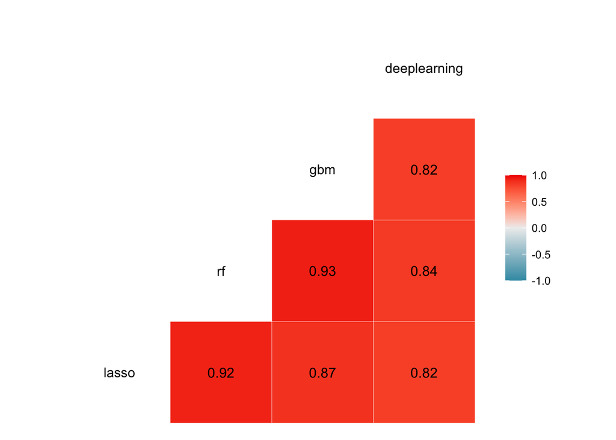

```r
# inspect correlations among scores from different models (on the out-of-fold samples)
as_tibble(level_1_features) %>%
  select(where(is.numeric)) %>%
  GGally::ggcorr(label = TRUE, label_round = 2)
```

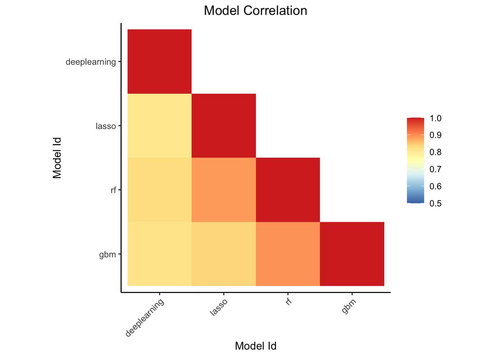

```r
# here we can calculate the correlation between the predictions for another data set
h2o.model_correlation_heatmap(my_models, data_test)
```

```r
# for the ensemble model
map_df(
  c(simple_models, my_models, ensemble_model),
  ~{tibble(model = .@model_id, auc = h2o.auc(h2o.performance(., newdata = data_test)))}
)
```

| model | auc |
| --- | --- |
| logit | 0.7125467 |
| simple_tree | 0.6747455 |
| lasso | 0.7121877 |
| rf | 0.7258661 |
| gbm | 0.7242174 |
| deeplearning | 0.7072750 |
| StackedEnsemble_model_R_1614936962565_7652 | 0.7284021 |

The baseline meta-learner is a glm model. You can try others:

```r
ensemble_model_gbm <- h2o.stackedEnsemble(
  X, y,
  training_frame = data_train,
  metalearner_algorithm = "gbm",
  base_models = my_models
)
```

```r
h2o.auc(h2o.performance(ensemble_model_gbm, newdata = data_test))
```

```
## [1] 0.7264528
```

### Stacking models gained during a grid-search

Meta-learning can also be built upon same-family, different hyperparameter models that you gain via a grid of hyperparameters.

```r
hyper_params <- list(learn_rate = c(0.1, 0.3), max_depth = c(3, 5, 7))

gbm_grid <- h2o.grid(
  x = X, y = y,
  training_frame = data_train,
  algorithm = "gbm",
  ntrees = 10,
  hyper_params = hyper_params,
  seed = 123,
  nfolds = 5,
  keep_cross_validation_predictions = TRUE
)
```

```r
ensemble_model_grid_gbm <- h2o.stackedEnsemble(
  X, y,
  training_frame = data_train,
  base_models = gbm_grid@model_ids
)
```

Compare performance

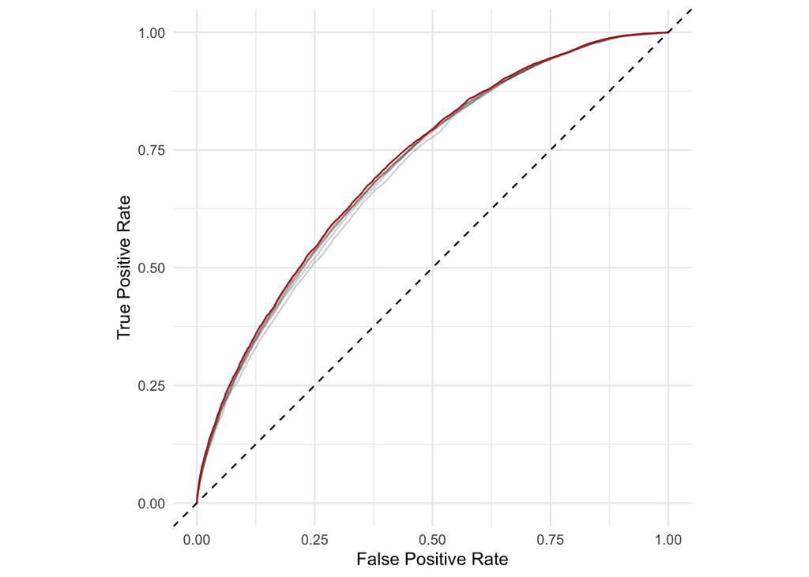

```r
gbm_performances <- map_df(gbm_grid@model_ids, ~{
  getPerformanceMetrics(h2o.getModel(.), newdata = data_test)
})

ensemble_performance <- getPerformanceMetrics(ensemble_model_grid_gbm, newdata = data_test)

ggplot(gbm_performances, aes(fpr, tpr, group = model)) +
    geom_path(alpha = 0.2) +
    geom_path(color = "firebrick", data = ensemble_performance) +
    geom_abline(slope = 1, intercept = 0, linetype = "dashed") +
    coord_fixed() +
    labs(x = "False Positive Rate", y = "True Positive Rate")
```